# Practical Machine Learning

dnrl

January 2016

Latest trend in exercising is measuring the amount or quanitity of exercise we do. Small devices that can be carried in a pocket, on a band, in a watch or shoe, can measure all of the movement of that user.  
Unfortunately, most of them do not measure the quality of the movement. This project will take data worn by individuals and determine how well the exercises were performed.

## Set up libraries and read data into files

```r
library(caret)
```

```r
library(ggplot2)
library(rpart.plot)
library(randomForest)
library(rattle)
setwd("C:/USERS/DON/PML/")
set.seed(2048)

inTraindata <- read.csv("pml-training.csv", header=T,na.strings=c("NA", "#DIV/0!",""))
Classdata <- read.csv("pml-testing.csv", header=T,na.strings=c("NA","#DIV/0!",""))
```

### Training data set “https://d396qusza40orc.cloudfront.net/predmachlearn/pml-training.csv”

### Class data set “https://d396qusza40orc.cloudfront.net/predmachlearn/pml-testing.csv”

Set up for the processing, clearing out NA and data that causes problem with the modeling from completing and compiling cleanly. Splitting the data file into 60% training and 40% testing.

```r
for(i in c(8:ncol(inTraindata)-1)) {inTraindata[,i] = as.numeric(as.character(inTraindata[,i]))}

for(i in c(8:ncol(Classdata)-1)) {Classdata[,i] = as.numeric(as.character(Classdata[,i]))}

Dataset <- colnames(inTraindata[colSums(is.na(inTraindata)) == 0])[-(1:7)]
model_set <- inTraindata[Dataset]
inTrain <- createDataPartition(y=model_set$classe, p=0.60, list=F)
training <- model_set[inTrain,]
testing <-  model_set[-inTrain,]
```

# Modeling the data.

Fit the data using rpart: Recursive Partitioning and Regression Trees

First to split it into 5 folds. fit it into the model with the classe data. predict for 60% of data and then against the othe 40%.

```r
traincontrol <- trainControl(method ="cv", number = 5)

rtfit <- train(classe ~ ., data = training, method = "rpart",trControl = traincontrol)
print(rtfit) #
```

```
## CART
##
## 11776 samples
##    52 predictor
##     5 classes: 'A', 'B', 'C', 'D', 'E'
##
## No pre-processing
## Resampling: Cross-Validated (5 fold)
##
## Summary of sample sizes: 9420, 9421, 9421, 9421, 9421
##
## Resampling results across tuning parameters:
##
##   cp          Accuracy   Kappa       Accuracy SD  Kappa SD
##   0.03654485  0.5118023  0.36286050  0.01803765   0.0237331
##   0.06031482  0.4429412  0.25354463  0.07127726   0.1193176
##   0.11770290  0.3496928  0.09955162  0.03648232   0.0557122
##
## Accuracy was used to select the optimal model using  the largest value.
## The final value used for the model was cp = 0.03654485.
```

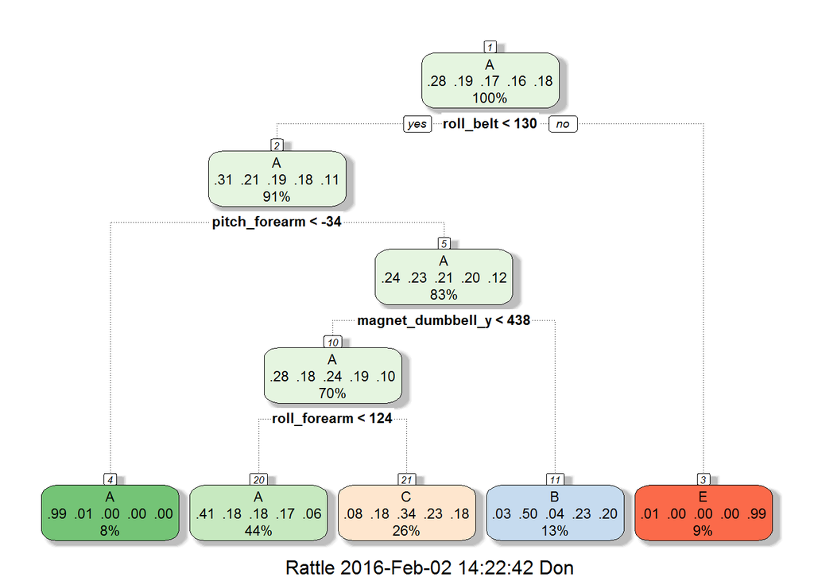

```r
fancyRpartPlot(rtfit$finalModel)
```

```r
predict_rpart <- predict(rtfit, training)
(conf_rpart <- confusionMatrix(training$classe, predict_rpart))
```

```
## Confusion Matrix and Statistics
##
##           Reference
## Prediction    A    B    C    D    E
##          A 3052   52  234    0   10
##          B  956  777  546    0    0
##          C  950   70 1034    0    0
##          D  858  354  718    0    0
##          E  300  310  553    0 1002
##
## Overall Statistics
##
##                Accuracy : 0.498
##                  95% CI : (0.489, 0.5071)
##     No Information Rate : 0.5194
##     P-Value [Acc > NIR] : 1
##
##                   Kappa : 0.344
##  Mcnemar's Test P-Value : NA
##
## Statistics by Class:
##
##                      Class: A Class: B Class: C Class: D Class: E
## Sensitivity            0.4990  0.49712  0.33517       NA  0.99012
## Specificity            0.9477  0.85293  0.88264   0.8361  0.89195
## Pos Pred Value         0.9116  0.34094  0.50341       NA  0.46282
## Neg Pred Value         0.6364  0.91724  0.78904       NA  0.99896
## Prevalence             0.5194  0.13273  0.26197   0.0000  0.08594
## Detection Rate         0.2592  0.06598  0.08781   0.0000  0.08509
## Detection Prevalence   0.2843  0.19353  0.17442   0.1639  0.18385
## Balanced Accuracy      0.7234  0.67503  0.60890       NA  0.94104
```

```r
predict_rpart <- predict(rtfit, testing)
(conf_rpart <- confusionMatrix(testing$classe, predict_rpart))
```

```
## Confusion Matrix and Statistics
##
##           Reference
## Prediction    A    B    C    D    E
##          A 2026   38  164    0    4
##          B  628  519  371    0    0
##          C  642   39  687    0    0
##          D  591  224  471    0    0
##          E  222  183  408    0  629
##
## Overall Statistics
##
##                Accuracy : 0.4921
##                  95% CI : (0.481, 0.5032)
##     No Information Rate : 0.5237
##     P-Value [Acc > NIR] : 1
##
##                   Kappa : 0.3359
##  Mcnemar's Test P-Value : NA
##
## Statistics by Class:
##
##                      Class: A Class: B Class: C Class: D Class: E
## Sensitivity            0.4931  0.51745  0.32699       NA  0.99368
## Specificity            0.9449  0.85401  0.88146   0.8361  0.88729
## Pos Pred Value         0.9077  0.34190  0.50219       NA  0.43620
## Neg Pred Value         0.6290  0.92351  0.78172       NA  0.99938
## Prevalence             0.5237  0.12784  0.26778   0.0000  0.08068
## Detection Rate         0.2582  0.06615  0.08756   0.0000  0.08017
## Detection Prevalence   0.2845  0.19347  0.17436   0.1639  0.18379
## Balanced Accuracy      0.7190  0.68573  0.60422       NA  0.94048
```

# Using Random Forest to model the same data to compare accuracy.

Fit model using random forests algorithm and 5-fold cross validation to predict classe with out all non-sensory predictors.

```r
rffit <- train(classe ~ ., data = training, method = "rf",trControl = traincontrol)
print(rffit)
```

```
## Random Forest
##
## 11776 samples
##    52 predictor
##     5 classes: 'A', 'B', 'C', 'D', 'E'
##
## No pre-processing
## Resampling: Cross-Validated (5 fold)
##
## Summary of sample sizes: 9420, 9421, 9421, 9421, 9421
##
## Resampling results across tuning parameters:
##
##   mtry  Accuracy   Kappa      Accuracy SD  Kappa SD
##    2    0.9864133  0.9828099  0.002284411  0.002892338
##   27    0.9876021  0.9843148  0.002773058  0.003509622
##   52    0.9797899  0.9744303  0.004445977  0.005624350
##
## Accuracy was used to select the optimal model using  the largest value.
## The final value used for the model was mtry = 27.
```

```r
predict_rf <- predict(rffit, training)
(conf_rf <- confusionMatrix(training$classe, predict_rf))
```

```
## Confusion Matrix and Statistics
##
##           Reference
## Prediction    A    B    C    D    E
##          A 3348    0    0    0    0
##          B    0 2279    0    0    0
##          C    0    0 2054    0    0
##          D    0    0    0 1930    0
##          E    0    0    0    0 2165
##
## Overall Statistics
##
##                Accuracy : 1
##                  95% CI : (0.9997, 1)
##     No Information Rate : 0.2843
##     P-Value [Acc > NIR] : < 2.2e-16
##
##                   Kappa : 1
##  Mcnemar's Test P-Value : NA
##
## Statistics by Class:
##
##                      Class: A Class: B Class: C Class: D Class: E
## Sensitivity            1.0000   1.0000   1.0000   1.0000   1.0000
## Specificity            1.0000   1.0000   1.0000   1.0000   1.0000
## Pos Pred Value         1.0000   1.0000   1.0000   1.0000   1.0000
## Neg Pred Value         1.0000   1.0000   1.0000   1.0000   1.0000
## Prevalence             0.2843   0.1935   0.1744   0.1639   0.1838
## Detection Rate         0.2843   0.1935   0.1744   0.1639   0.1838
## Detection Prevalence   0.2843   0.1935   0.1744   0.1639   0.1838
## Balanced Accuracy      1.0000   1.0000   1.0000   1.0000   1.0000
```

```r
predict_class <- predict(rffit, Classdata)

predict_class
```

```
##  [1] B A B A A E D B A A B C B A E E A B B B
## Levels: A B C D E
```